# Урок 2

### 1.Git

### 2 Операторы, выражения.

### 3 Переменные. Стандартный ввод/вывод

### 4 Логические операции, операции сравнения

### 5 Условия: if, else, elif. Блоки, отступы

### 6 Строки

```python
print()
```

```python
type()
```

```python
int(6.4)
```

```
6
```

```python
float()
```

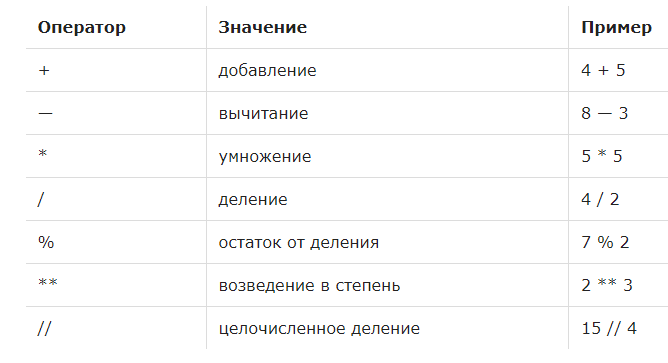

```python
round(1.5)
round(2.5)
round(2.65, 1)
round(2.75, 1)
```

```
2.8
```

```python
print(round(1.5))
print(round(2.5))
print(round(2.65, 1))
print(round(2.65, 0))
print(round(2.75, 1))
```

```
2
2
2.6
3.0
2.8
```

```python
print(round(-1.5))
print(round(-2.5))
print(round(-2.65, 1))
print(round(-2.65, 0))
print(round(-2.75, 1))
```

```
-2
-2
-2.6
-3.0
-2.8
```

Round округляет по "банковским" правилам, т.е. к ближайшему чётному, а не по правилам математического округления.

```python
print(int(1.5))
print(int(2.5))
print(int(2.65))
print(int(2.75))
```

```
1
2
2
2
```

```python
print(int(abs(-2.75)))
```

```
2
```

```
int(x) - Округляет число в сторону нуля. Это стандартная функция, для ее использования не нужно подключать модуль math.
round(x) - Округляет число до ближайшего целого. Если дробная часть числа равна 0.5, то число округляется до ближайшего четного числа.
round(x, n) - Округляет число x до n знаков после точки. Это стандартная функция, для ее использования не нужно подключать модуль math
abs(x) - Модуль (абсолютная величина). Это — стандартная функция.
```

```python
print(abs(-1.5))
print(abs(2.5))
print(abs(-2.65))
print(abs(2.75))
```

```
1.5
2.5
2.65
2.75
```

https://realpython.com/python-rounding/

# Git

[figure not shown]

GitHub это система управления проектами и версиями кода, а также платформа социальных сетей, созданная для разработчиков. Но для чего используется GitHub? Ну, среди прочего, это позволяет вам работать совместно с другими людьми по всему миру, планировать свои проекты и отслеживать свою работу.

GitHub также является одним из крупнейших онлайн-хранилищ (англ) совместной работы по всему миру.

Прежде чем мы перейдём дальше, мы должны понять, что такое Git. Это как сердце GitHub. Git — это система контроля версий, разработанная Линусом Торвальдсом (человеком, создавшим Linux).

Git — это система контроля версий, разработанная Линусом Торвальдсом (человеком, создавшим Linux).

Если Git — это сердце GitHub, то Hub — это его душа. Концентратор в GitHub — это то, что превращает командную строку, такую как Git, в крупнейшую социальную сеть для разработчиков.

Помимо участия в определённом проекте, GitHub позволяет пользователям общаться с единомышленниками. Вы можете следить за людьми и смотреть, что они делают или с кем они общаются.

Репозиторий или хранилище — это каталог, в котором хранятся файлы вашего проекта. Он может быть расположен в хранилище GitHub или в локальном хранилище на вашем компьютере. Вы можете хранить файлы кодов, изображения, аудио или всё, что связано с проектом, в хранилище.

Ветка это копия вашего репозитория. Вы можете использовать ветку, когда хотите сделать разработку изолированно.

Работа с веткой не повлияет на центральное хранилище или другие ветки. Если вы сделали эту работу, вы можете объединить свою ветку с другими ветками и центральным репозиторием, используя запрос на извлечение.

Как мы разобрались выше, Git — это инструмент, позволяющий реализовать распределённую систему контроля версий.

GitHub — сервис онлайн-хостинга репозиториев, обладающий всеми функциями распределённого контроля версий и функциональностью управления исходным кодом — всё, что поддерживает Git и даже больше. Также GitHub может похвастаться контролем доступа, багтрекингом, управлением задачами и вики для каждого проекта.

Кроме GitHub есть другие сервисы, которые используют Git, — например, Bitbucket и GitLab. Вы можете разместить Git-репозиторий на любом из них.

https://tproger.ru/articles/5-shpargalok-po-git-ot-osnov-do-raboty-s-github/

Каждая точка сохранения вашего проекта носит название коммит (commit). У каждого commit-a есть hash (уникальный id) и комментарий. Из таких commit-ов собирается ветка. Ветка - это история изменений. У каждой ветки есть свое название. Репозиторий может содержать в себе несколько веток, которые создаются из других веток или вливаются в них.

Если посмотреть на картинку, то становиться чуть проще с пониманием. Каждый кружок, это commit. Стрелочки показывают направление, из какого commit сделан следующий. Например C3 сделан из С2 и т. д. Все эти commit находятся в ветке под названием main. Это основная ветка, чаще всего ее называют master . Прямоугольник main* показывает в каком commit мы сейчас находимся, проще говоря указатель.

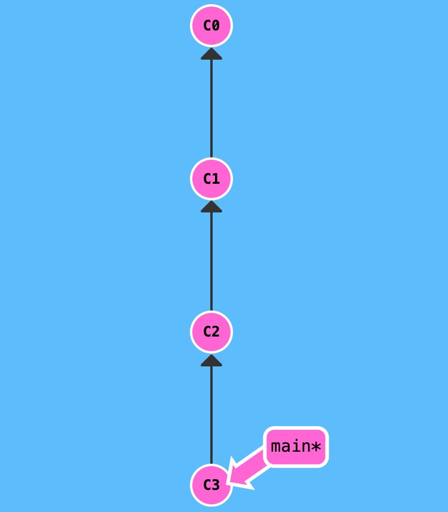

В итоге получается очень простой граф, состоящий из одной ветки (main) и четырех commit. Все это может превратиться в более сложный граф, состоящий из нескольких веток, которые сливаются в одну.

Основой интерфейс для работы с Git-ом является консоль/терминал. Это не совсем удобно, тем более для новичков, поэтому предлагаю поставить дополнительную программу с графическим интерфейсом (кнопками, графиками и т.д.). О них я расскажу чуть позже.

Но для начала, все же установим сам Git.

Windows. Проходим по этой ссылке, выбираем под вашу ОС (32 или 64 битную), скачиваем и устанавливаем.

Для Mac OS. Открываем терминал и пишем:

# Если установлен Homebrew

brew install git

# Если нет, то вводим эту команду.

git --version

# После этого появится окно, где предложит установить Command Line Tools (CLT).

# Соглашаемся и ждем установки. Вместе с CLT установиться и git

Linux. Открываем терминал и вводим следующую команду.

### Debian или Ubuntu

sudo apt install git

# Для Linux и MacOS путь может выглядеть так /Users/UserName/Desktop/MyProject

# Для Windows например С://MyProject

cd <путь_к_вашему_проекту>

# Инициализация/создание репозитория

git init

Теперь Git отслеживает изменения файлов вашего проекта. Но, так как вы только создали репозиторий в нем нет вашего кода. Для этого необходимо создать commit.

# Добавим все файлы проекта в нам будующий commit

git add .

# Или так

git add --all

# Если хотим добавить конкретный файл то можно так

git add <имя_файла>

# Теперь создаем commit. Обязательно указываем комментарий.

# И не забываем про кавычки

git commit -m "<комментарий>"

Отлично. Вы создали свой первый репозиторий и заполнили его первым commit.

Процесс работы с Git Не стоит после каждого изменения файла делать commit. Чаще всего их создают, когда:

Создан новый функционал

Добавлен новый блок на верстке

Исправлены ошибки по коду

Вы завершили рабочий день и хотите сохранить код

Это поможет держать вашу ветки в чистоте и порядке. Тем самым, вы будете видеть историю изменений по каждому нововведению в вашем проекте, а не по каждому файлу.

git remote add origin адрес вашего Гита

Это добавляет новый удаленный сервер гитхаба в список серверов куда мы можем пушить. Origin это название сервера. Обычно оно стандартное хотя вы можете выбрать любое имя.

То что он у нас добавился мы можем посмотреть командой

git remote -v

И оно нам выводит репозиторий, который мы добавили.

git push -u origin master

В консоли оно запрашивает логин и пароль. Вводим оба. Видим сообщение что данные были записаны в нашу репу на гитхабе.

Теперь если мы обновим окно репозитория в браузере, то мы увидим наш репозиторий на гитхабе.

И напоследок в этом уроке еще 2 команды. Первая команда это

git pull

Все что она делает, это сливает в проект новые изменения если они есть из удаленного репозитария. В нашем случае с гитхаба. В нашем случае оно написало что проект up to date так как у нас последние изменения. Но если мы вы дома сделали какие-то изменения, запушили, пришли на работу и написали бы git pull, то оно бы стянуло изменения, которые вы сделали в проекте дома, если вы конечно не забыли их запушить.

Вторую команду вы впринципе уже видели когда мы пушили наши изменения на гитхаб. Это команда

git push

Это очень популярная команда. Если вы хотите запушить ваши изменения на сервер, то вы всегда ее изпользуете. Давайте создадим файл 2.js и запушим его на гитхаб.

touch 2.js git add . git commit -m "Added 2.js" git push

## Переменные

Переменная это такая штука (число/строка/объект), которую мы обозначаем особой меткой.

Можно называть переменные русскими буквами. Если вы так будете делать, у вас не будет друзей

```python
ученики = 10
print(ученики)
```

```
10
```

Вообще, названия переменных могут (должны) содержать только a-zA-Z, символ _ и цифры, если цифра это не первое

Kогда вы используете переменные в Python, вам нужно придерживаться нескольких правил и рекомендаций. Нарушение некоторых из этих правил приведет к ошибкам; другие рекомендации просто помогают писать код, который легче читать и понимать. Обязательно помните о следующих правилах переменных:

Имена переменных могут содержать только буквы, цифры и символы подчеркивания. Они могут начинаться с буквы или подчеркивания, но не с числа. Например, вы можете вызвать переменную message_1, но не 1_message. В именах переменных нельзя использовать пробелы, но для разделения слов в именах переменных можно использовать подчеркивание. Например, welcome_message работает, но приветственное сообщение вызовет ошибки. Избегайте использования ключевых слов Python и имен функций в качестве имен переменных; то есть не используйте слова, зарезервированные Python для определенных программных целей, например слово print. Имена переменных должны быть короткими, но информативными. Например, name лучше, чем n, student_name лучше, чем s_n, а name_length лучше, чем length_of_persons_name. Будьте осторожны при использовании строчной буквы l и прописной буквы O, потому что их можно спутать с числами 1 и 0.

### a = 3

```python
x=1
```

```python
x += 4
```

```python
x += 4
```

```python
x += 4
```

```python
x += 4
```

```python
x
```

```
17
```

```python
a += 4
```

```python
a
```

[output not shown]

```python
2 * a
```

```
14
```

```python
print(a)
print(2 * a)
```

```
7
14
```

print() - выводит строку на печать

Задача - поменять переменные местами

```python
x = 5.5
y = 10
y=True
```

```python
temp = x
```

```python
temp
```

[output not shown]

```python
temp = x

x = y
y = temp
```

```python
x = y
```

```python
x
```

[output not shown]

```python
x, y = y, x
```

```python
print (x,y, sep='$', end='privet')
```

```
True$5.5privet
```

```python
print (x,y,temp, sep=' ', end='\n')
```

```python
print (x,y,temp, )
```

По-умолчанию разделителями между строками при выводе внутри print будут пробелы, а послеокончания вывода с помощью print будет поставлен перенос строки. Изменить эти значения можно с помощью параметров sep и end, соответственно:

```python
a = int(float(input()))
```

```
4
```

```python
a='6.4'
```

```python
a=float(a)
```

```python
a
```

```
6.4
```

```python
int(a)
```

```
6
```

```python
a=input()
```

```
6
```

```python
6.0
```

```
6.0
```

```python
a = int(input())
b = int(input())
print(a * b)
```

```python
name = input()
print(name)
```

```
Daniil
Daniil
```

input() - возвращает строку из стандартного потока ввода (например, с клавиатуры до нажатия на клавишу Enter)

Как параметр можно указать сообщение, которое будет выводиться перед вводом ("приглашение к вводу").

```python
name = input('Enter your name: ')
print('Hello', name)
```

```
Enter your name: asdadad
Hello asdadad
```

## Строки

Строки в Python - упорядоченные последовательности символов, используемые для хранения и представления текстовой информации.

Всё что мы вводим с клавиатуры (input) или читаем из файлов (open, read, readline) будет строками.

```python
a = 'string'
b = "another string"
print(a, b)
```

```
string another string
```

В переменную a записали строку "string" (апострофы используются для обозначения начала и конца строки). Кавычки так же могут быть использованы для записи строк.

Всё содержимое строковой переменной считается строкой до тех пор, пока вновь не встретится литерал, идентичный началу строку (апостроф, кавычки, тройные апострофы или кавычки):

```python
print("Привет, МИСИС")
```

```
Привет, МИСИС
```

```python
print("Привет" + ", " + "МИСИС")
```

```
Привет, МИСИС
```

```python
привет_мисис = "Привет, МИСИС!"
print(привет_мисис)
```

```
Привет, МИСИС!
```

```python
hello = "Привет"
misis = "МИСИС"
print(hello + ", " + misis)
```

```
Привет, МИСИС
```

```python
text='Результат вычисления'
resa='10'
```

```python
print(text + ": " + str(text))
```

```
Результат вычисления: Результат вычисления
```

```python
str2='"Zara"'

print(str2+str(x))
```

[output not shown]

```python
str='sdsd'
```

```python
sep='sdsd'
```

```python
sep
```

```
'sdsd'
```

```python
print('one', 'two', sep='spase')
```

```
onespasetwo
```

```python
hello = "Привет" # главное чтобы парные
# всё что после символа '#' до конца строки это комментарий
person_or_entity="МИСИС"

print("Привет, %s" % person_or_entity)
print(hello + ", " + person_or_entity)
print(f"{hello}, {person_or_entity}")
print(", ".join([hello, person_or_entity]))
```

```
Привет, МИСИС
Привет, МИСИС
Привет, МИСИС
Привет, МИСИС
```

```python
name=42.7250
surname=753000004
```

```python
surname=2.718281828
name=3.1415926
```

```python
name=42.7250
surname=753000004
print(f'{hello} {name:.2f} {surname}')
print("%s %.2f %g" % (hello, name, surname))
print(" -,2 ".join([hello, str(name), str(surname)]))
```

```
Привет 42.73 753000004
Привет 42.73 7.53e+08
Привет -,2 42.725 -,2 753000004
```

мы использовали разные модификации вывода, про них можно почитать подробно в документации. Вообще же, рекомендую использовать первый вариант с f-строками, он наиболее компактный на мой взгляд.

https://pythonworld.ru/osnovy/formatirovanie-strok-metod-format.html

https://pythonworld.ru/osnovy/formatirovanie-strok-operator.html

template.format(p0, p1, ..., k0=v0, k1=v1, ...)

Здесь p0, p1,... — это позиционные аргументы, а k0, k1,... — аргументы-ключевые слова со значениями v0, v1,... соответственно.

А template — это набор строк с заполнителями для аргументов.

```
Параметры format()
Метод format() принимает любое количество параметров. Но они делятся на два вида:
Позиционные аргументы — список параметров, доступ к которым можно получить по индексу параметра в фигурных скобках {индекс}.
Параметры — ключевые слова — список параметров типа ключ=значение, доступ к которым можно получить с помощью ключа параметра в фигурных скобках {ключ}.
```

Формат читает тип переданных аргументов и форматирует строку в соответствии с кодами форматирования в строке.

https://pythonru.com/osnovy/formatirovanie-v-python-s-pomoshhju-format

```python
obj = 46.2
```

```python
print(type(obj))
```

```
<class 'float'>
```

```python
abs(obj)
```

```
46.2
```

```python
print(dir(obj))
```

[output not shown]

```python
obj = "Сосисочка"
print(dir(obj))
print(type(obj))
```

[output not shown]

```python
obj = "стРОкА".upper()
print(obj.upper(), obj.lower(), obj.title())
print(obj.isalpha(), obj.isdigit())
print(obj.center(50))
```

```
СТРОКА строка Строка
True False
                      СТРОКА
```

Чтобы посмотреть помощь по какой-то функции, используйте встроенную функцию help:

```python
help(obj.center)
```

```
Help on built-in function center:

center(width, fillchar=' ', /) method of builtins.str instance
    Return a centered string of length width.

    Padding is done using the specified fill character (default is a space).
```

Функция len() возвращает длину (количество элементов) в объекте.

```python
len('abcdef')
```

```
6
```

Все методы, название которых начинается с двух подчёркиваний являются служебными. Это не значит, что их нельзя вызывать напрямую, надо просто иметь в виду что они будут вызываться, когда интерпретатор увидит соответствующий оператор. Это удобно, потому что их можно перегружать для своих кастомных классов

```python
a = 15
print(a + 5)
print(a.__add__(5))
print(a < 10)
print(a.__lt__(10))  # lt от less than
```

```
20
20
False
False
```